# Comparação do Vetor de Médias Populacionais

Vicente G. Cancho

# *Introdução*

- As ideias da aula anterior (inferência sobre um vetor de média) podem ser usadas para desenvolver procedimentos para comparação de dois ou mais vetores de médias populacionais. Estudaremos primeiro essas comparações quando os dados surgirem de um delineamento pareado (medidas antes/depois ou duas condições diferentes), depois quando os dados surgirem de mais de dois tratamentos.
- Inicialmente revisaremos os procedimentos univariados para cada uma das duas situações e, em seguida, generalizaremos essas ideias para situações multivariadas.

# *Amostras emparelhadas*

O termo “emparelhada” refere-se à situação em que cada unidade da amostra é medida duas vezes, como receber dois tratamentos ou condições experimentais diferentes.

## *Exemplo 1: Teste de dureza de uma esfera de aço*

Em um teste de dureza, uma esfera de aço é pressionada contra a superfície de um bloco de material a uma carga padrão. Mede-se o diâmetro (em mm) da cavidade produzida, que está relacionado à dureza do material da superfície. Na realização do teste duas esferas (A e B) estão disponíveis. Suspeita-que a esfera A gera cavidades com diâmetro médio igual à esfera B. As duas **esferas** foram utilizadas em 10 blocos (n = 10) obtendo-se os dados abaixo:

Tabele with kable

| Bloco | A | B |
| --- | --- | --- |
| 1 | 7.5 | 5.2 |
| 2 | 4.6 | 4.1 |
| 3 | 5.7 | 4.3 |
| 4 | 4.3 | 4.7 |
| 5 | 5.8 | 3.2 |
| 6 | 3.2 | 4.9 |
| 7 | 6.1 | 5.2 |
| 8 | 5.6 | 4.4 |
| 9 | 3.4 | 5.7 |
| 10 | 6.5 | 6.0 |

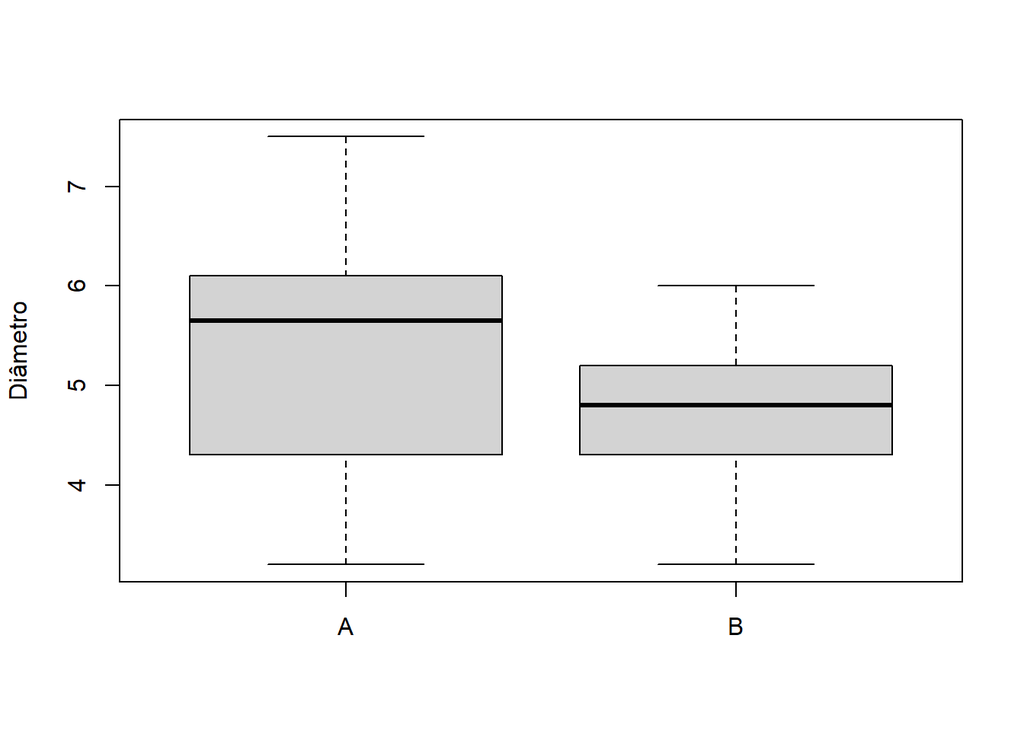

O que os dados permitem concluir sobre a suspeita formulada? Adote $\alpha$ = 5%

### Amostras dependentes

Seja :

- $X_{1j}:$ o diâmetro do $j$-ésimo bloco ma espera A.
- $X_{2j}:$ o diâmetro do $j$-ésimo bloco ma espera B
- $(x_{11},x_{21}),\ldots, (x_{1n},x_{2n})$ amostra observada de $n$ indivíduos, em que uma caracteristica foi medida em dois períodos.
- são observações bivariadas, mas $x_{1i}$ e $x_{2i}$ são correlacionadas

#### Caso I: Amostra das diferenças

Seja

$$D_i=X_{1i}-X_{2i},\; i=1,\ldots, n$$
uma amostra de $n$ pares de observações.
Supor

- Os $D_i$´s são variáveis aleatórias independentes
- Os $D_i$ tem distribuição normal com média $\mu_D=\mu_1-\mu_2$ e variância $\sigma^2_D$.

#### Estimador de $\mu_D$ e $\sigma^2_D$

Hipóteses de interesse
$$H_0:\mu_D=\delta_0,\\ H_1: \mu_D\ne
\delta_0$$
que é equivalente
$$H_0:\mu_1-\mu_2=\delta_0,\\ H_1: \mu_1-\mu_2 \ne
\delta_0$$
Pode-se mostrar que a estatíca de teste,
$$T=\frac{\overline{D}-\delta_0}{S_D/\sqrt{n}}$$

sob $H_0$ tem distribuição t-Student com n-1 graus de liberdade.

Dado o nível de significância rejeita-se $H_0$ se $T_{obs}> t_{n-1}(1-\alpha/2).$

Um intervalo de $100(1-\alpha)\%$ de confiança para $\mu_D=\mu_1-\mu_2$ é dado por
$$\overline{D}\pm t_{n-1}(1-\alpha/2)\frac{S_d}{\sqrt{n}}.$$

```r
D=A-B
t.test(D,alternative = "two.sided")
```

```
##
##  One Sample t-test
##
## data:  D
## t = 0.99779, df = 9, p-value = 0.3445
## alternative hypothesis: true mean is not equal to 0
## 95 percent confidence interval:
##  -0.6335893  1.6335893
## sample estimates:
## mean of x
##       0.5
```

#### Caso II: Amostra Bivariadas

Seja $(x_{11},x_{21}),\ldots, (x_{1n},x_{2n})$ uma amostra observada de $n$ indivíduos vem de uma população com distribuição normal bivariâda com vetor de médias $\boldsymbol{\mu}$ e matriz de covariâncias $\Sigma$, ou seja, a população de f.d.p conjunta dada por
$$f(\boldsymbol{x})=(2\pi)^{-1} |\Sigma|^{-1/2}
\exp\left\{-\frac{1}{2}(\boldsymbol{x}-\boldsymbol{\mu})^\top\Sigma^{-1}(\boldsymbol{x}-\boldsymbol{\mu})\right\},\;
\boldsymbol{x}\in R^2.$$
onde $\boldsymbol{x}={x_1\choose x_2}$, $\boldsymbol{\mu}={\mu_1\choose \mu_2}$ e $\Sigma=\left(\begin{array}{ll} \sigma_{11}& \sigma_{12}\\ \sigma_{21}& \sigma_{22} \end{array}\right).$ ### Interência

- O estimador de $\boldsymbol(\mu)$ e $\Sigma$ são respectivamente $\bar{\boldsymbol{x}}$ (vetor de médias amostrais) e $S$ (matriz a covariância amostral)
- A hipótese de interesse
  $$H_0:\mu_1-\mu_2=\delta_0\Longrightarrow
  H_0:\boldsymbol{c}\boldsymbol{\mu}=\delta_0\\
  H_1:\mu_1-\mu_2\ne\delta_0\Longrightarrow
  H_1:\boldsymbol{c}\boldsymbol{\mu}\ne\delta_0$$
  onde $c=(1,-1)$.
- A estatística de teste
  $$T^2=n(c\boldsymbol{\bar{x}}-\delta_0)^\top
  (c^\top S c)^{-1}(c\boldsymbol{\bar{x}}-\delta_0),$$
  sob $H_0$ tem distribuição F com 1 e n-1 graus de liberdade.

```r
barx=colMeans(dados[,-1])
S=cov(dados[,-1])
n=nrow(dados)
c=c(1,-1)
T2=n*(t(c)%*%barx)*solve(t(c)%*%S%*%(c))*t(t(c)%*%barx)
p_valor=1-pf(T2,1,n-1)

res=cbind(T2,p_valor)
colnames(res)=c(" T^2","P-valor")
res
```

```
##            T^2   P-valor
## [1,] 0.9955752 0.3444525
```

# *Amostras emparelhadas multivariadas*

## *Exemplo 2: Risco Cardiovascular*

Num estudo do risco cardiovascular foram considerados variáveis referentes a medições cardíacas de 223 indivíduos. Para cada um dos indivíduos, as variáveis foram coletadas em duas posições: (1) Supina e (2) Inclinada.

- Seja $\boldsymbol{X}_i$ o vetor aleatório de 4 medições na posição $i,$ $i=1,2,$ com componentes representando as seguintes medições:
  - $X_{i1}$ taxa cardíaca,
  - $X_{i2}$ saída cardíaca,
  - $X_{i3}$ resistência vascular sistêmica,
  - $X_{i4}$ velocidade do pulso de onda.
- Note que $\boldsymbol{X}_1^\top =(X_{11},X_{12},X_{12},X_{14})$ e $\boldsymbol{X}_2^\top =(X_{21},X_{22},X_{22},X_{24})$ são correlacionados, pois são mensurações no mesmo indivíduo (dados pareados).
- Um grande interesse nesse tipo de estudo é avaliar se as medições cardíacas são iguais nas duas posições.
- Nesse caso, é necessário avaliar se as médias dos vetores aleatórios $\boldsymbol{X}_1$ e $\boldsymbol{X}_2$ são iguais.
- Isso é equivalente a testar a a diferença de medições cardíacas nas duas diferentes posições.
- Para representar essa diferença, seja $\boldsymbol{D} = \boldsymbol{X}_1- \boldsymbol{X}_2.$
- Uma amostra desse vetor de diferenças pode ser obtida em função das amostras das medições dos indivíduos nas duas diferentes posições.

```r
library(ICSNP)
## Dados das diferenças das variáveis nas posições 1 e 2.

data(LASERI)

# filtrando as variáveis de interesse em um novo data.frame

cardio <- LASERI[,c("HRT1T4","COT1T4","SVRIT1T4","PWVT1T4")]

# renomeando variáveis
names(cardio) <- c("Taxa", "Saida","resist_Vascular","Veloc_Pulso")
head(cardio)
```

```
##   Taxa Saida resist_Vascular Veloc_Pulso
## 1   11  1.35            -470        -0.3
## 2    0  0.33            -130        -0.2
## 3    1  1.36            -407        -1.1
## 4  -13  1.28            -587        -6.9
## 5    4  1.07            -305         0.0
## 6    8  0.72            -635        -0.5
```

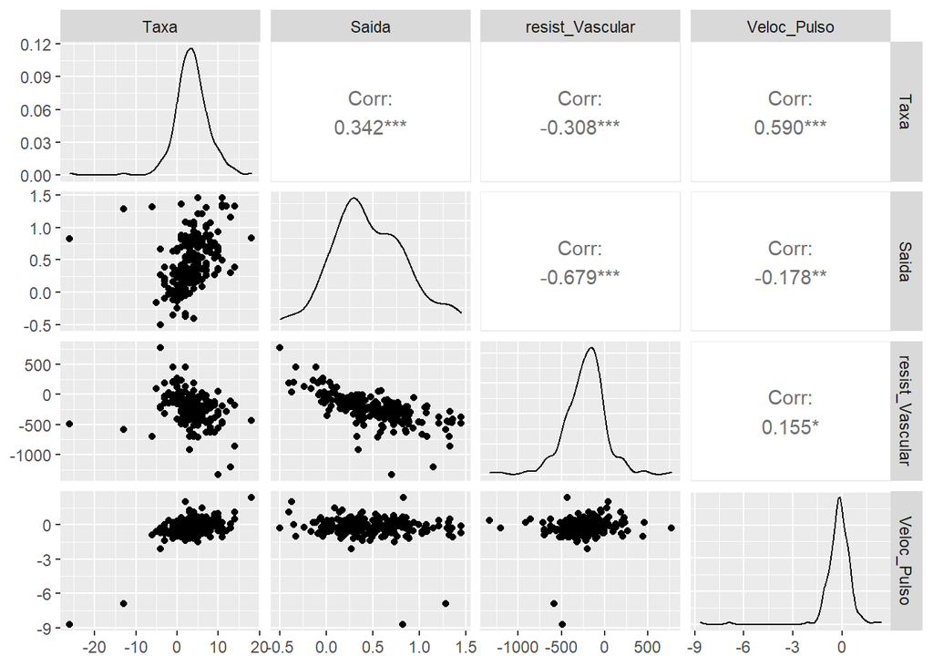

```r
library("ggplot2")
library("GGally")
require(car)
ggpairs(cardio)
```

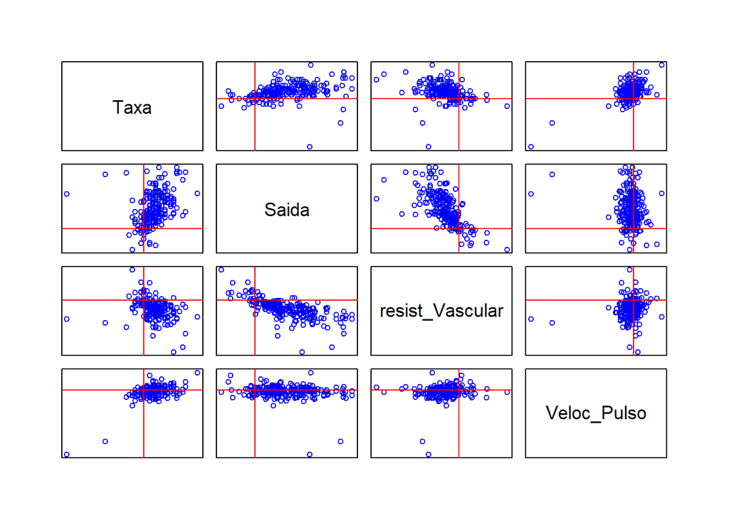

```r
#matriz de gráficos de dispersão
plotfun <- function(x,y,...){
    points(x,y,...)
    abline(h = 0, col="red")
    abline(v = 0, col="red")
}
pairs(cardio, xaxt="n", yaxt="n", col="blue", panel=plotfun)
```

Sejam

- $\boldsymbol{X}_{11},\ldots,\boldsymbol{X}_{1n}$ vetores aleatórios $p\times 1$ referentes a uma população normal multivariada {antes} de um tratamento com {$E(\boldsymbol{X}_{1j})=\boldsymbol{\mu}_1$} para $j=1,\ldots,n$,
- $\boldsymbol{X}_{21},\ldots,\boldsymbol{X}_{2n}$ vetores aleatórios $p\times 1$ referentes a uma população normal multivariada {após} de um tratamento com {$E(\boldsymbol{X}_{2j})=\boldsymbol{\mu}_2$} para $j=1,\ldots,n$,
- sendo que $\boldsymbol{X}_{1j}$ e $\boldsymbol{X}_{2j}$ são correlacionadas (por exemplo, vetores aleatórios de medições antes e após um tratamento).
- Sejam $\boldsymbol{\mu}_1$ e $\boldsymbol{\mu}_2$ os vetores de médias em situações 1 e 2, respectivamente.
- Deseja-se testar se não há diferença entre as situações 1 e 2 para verificar, por exemplo, que o tratamento não produz nenhum efeito, ou seja, se $\boldsymbol{\mu}_1 = \boldsymbol{\mu}_2$.
- A hipóteses anterior é equivalente a,
  $$\begin{array}{l}H_0:\boldsymbol{\mu}_D=\boldsymbol{0}\mbox{
  }\\H_1:\boldsymbol{\mu}_D\neq\boldsymbol{0}\end{array}.$$
- Pode-se mostrar que o teste da razão de verosimilhança tem distribuição $T^2$ de Hotelling, ou seja,
  $$T^2 =
  n(\bar{\boldsymbol{D}}-\boldsymbol{0})^\top S_D^{-1}
  (\bar{\boldsymbol{D}}-\boldsymbol{0})\stackrel{sob \ H_0}\sim
  \frac{(n-1)p}{n-p}F_{p,n-p},$$
  em que $\bar{\boldsymbol{D}}$ e $S_D$ são o vetor de médias e a matriz de variâncias e covariâncias amostrais de $\boldsymbol{D}$.
- Hipóteses de interesse:
  $$H_0:\boldsymbol{\mu}_1=\boldsymbol{\mu}_2,\;
  H_1:\boldsymbol{\mu}_1\neq\boldsymbol{\mu}_2$$
- Considera-se as diferenças:
  $$\boldsymbol{D}_j = \boldsymbol{X}_{1j}-\boldsymbol{X}_{2j},\;
  j=1,\ldots, n$$
- Supor, $\boldsymbol{D}_1,\ldots,\boldsymbol{D}_n$ é uma amostra aleatória de uma população $N_p(\boldsymbol{\mu}_D, \Sigma_D)$, com $\boldsymbol{\mu}_D=\boldsymbol{\mu}_1-\boldsymbol{\mu}_2.$
- Um teste análogo poderia ser desenvolvido para avaliar
  $$\begin{array}{l}H_0:\boldsymbol{\mu}_D=\boldsymbol{\delta}_{0}\mbox{
  }\\H_1:\boldsymbol{\mu}_D\neq\boldsymbol{\delta}_{0}\end{array},$$
  onde $\delta_{0}$ é conhecido.
- A estatística de teste é
  $$T^2 =
  n(\bar{\boldsymbol{D}}-\boldsymbol\delta_{0})^\top S_D^{-1}
  (\bar{\boldsymbol{D}}-\boldsymbol\delta_{0})\stackrel{ sob \ H_0}{\sim}
  \frac{(n-1)p}{n-p}F_{p,n-p}.$$
- Região de confiança
  $$\{\boldsymbol{\mu}_D;
  (\bar{\boldsymbol{D}}-\boldsymbol\delta_{0})^\top S_D^{-1}
  (\bar{\boldsymbol{D}}-\boldsymbol\delta_{0})
  \leq \frac{(n-1)p}{(n-p)n}q_{F_{p,n-p,\alpha} }\}$$
  onde $q_{F_{p,n-p,\alpha} }$ é o quantil $\alpha$ superior da distribuição F com p e n-p graus de liberdade.
- Intervalos de confiança simultâneos $T^2$ de Hotelling para cada componente da diferença
  $$\bar{D}_i\mp\sqrt{\frac{(n-1)p}{(n-p)n}q_{F_{p,n-p,\alpha}}}
  \sqrt{\frac{s_{d_i}}{n}},\; i=1,\ldots,p$$
  onde $\bar{D}_i$ é a diferença média da $i$-ésima variável e $s_{d_i}$ é o i-ésimo elemento diagonal de $S_D$.
- Intevalos de confiança de Bonferroni
  $$\bar{D}_i\mp
  F^{-1}{T_{(n-1)}}(1-\frac{1}{2m})\sqrt{\frac{s_{d_i}}{n}},\;
  i=1,\ldots,p$$
  onde $m$ é numero de intervalos (comparações).
- Para (n - p) grande (ou seja, $\boldsymbol{D}_j$ não precisa ser normal multivariado)
  $$n(\bar{\boldsymbol{D}}-\boldsymbol{\delta}_0)^\top S_D^{-1}
  (\bar{\boldsymbol{D}}-\boldsymbol{\delta}_0)\stackrel{sob \
  H_0}{\approx} \chi^3_{(p)}$$

```r
n=nrow(cardio)
p=ncol(cardio)
cor(cardio)
```

```
##                       Taxa      Saida resist_Vascular Veloc_Pulso
## Taxa             1.0000000  0.3422941      -0.3084791   0.5902124
## Saida            0.3422941  1.0000000      -0.6788780  -0.1778891
## resist_Vascular -0.3084791 -0.6788780       1.0000000   0.1548904
## Veloc_Pulso      0.5902124 -0.1778891       0.1548904   1.0000000
```

```r
# Vetor de Médias
D_bar=cbind(colMeans(cardio))
D_bar
```

```
##                         [,1]
## Taxa               3.5291480
## Saida              0.4668161
## resist_Vascular -224.3542601
## Veloc_Pulso       -0.2121076
```

```r
# Matriz de variância-covariância

S_d=var(cardio)
## Estatística observada
T2=n*t(D_bar)%*%solve(S_d)%*%(D_bar)
T2
```

```
##          [,1]
## [1,] 412.2676
```

```r
## Valor crítico para alpha =0,05

c=p*(n-1)*qf(0.05,p, n-p, lower.tail=F)/(n-p)
c
```

```
## [1] 9.783692
```

```r
## Alternativamente
f=T2*(n-p)/(p*(n-1))
f
```

```
##          [,1]
## [1,] 101.6741
```

```r
pf(f,p ,n-p,lower=F)
```

```
##              [,1]
## [1,] 8.613725e-49
```

```r
HotellingsT2(cardio)
```

```
##
##  Hotelling's one sample T2-test
##
## data:  cardio
## T.2 = 101.67, df1 = 4, df2 = 219, p-value < 2.2e-16
## alternative hypothesis: true location is not equal to c(0,0,0,0)
```

```r
##################################################
# Intervalos  simulatânea de 95% de confiança
##################################################

crit <- qf(0.05, p, n - p, lower.tail = F)
# Máximo erro
E <- sqrt((n-1)*p*crit/(n-p))* sqrt(diag(S_d)/n)
# intervals
LI = D_bar -  E
LS = D_bar +  E

Res=cbind(D_bar, LI, LS)
colnames(Res)=c("D_bar", "LI","LS")
print(Res,digits=3)
```

```
##                    D_bar       LI        LS
## Taxa               3.529    2.621    4.4373
## Saida              0.467    0.387    0.5471
## resist_Vascular -224.354 -275.361 -173.3471
## Veloc_Pulso       -0.212   -0.409   -0.0155
```

```r
##################################################
# Intervalos  de 95% de confiança de Bonferroni
##################################################

crit <- qt(0.05/(2*4), n-1, lower.tail = F)
# Máximo erro
E <- crit* sqrt(diag(S_d)/n)
# intervals
LI = D_bar -  E
LS = D_bar +  E

Res=cbind(D_bar, LI, LS)
colnames(Res)=c("D_bar", "LI","LS")
print(Res,digits=3)
```

```
##                    D_bar       LI        LS
## Taxa               3.529    2.798    4.2603
## Saida              0.467    0.402    0.5315
## resist_Vascular -224.354 -265.419 -183.2891
## Veloc_Pulso       -0.212   -0.370   -0.0539
```

# *Amostras Independentes*

Duas amostras, cada uma tendo $p$ medições onde nós ter uma amostra aleatória de tamanho $n_1$ da população 1 e uma amostra aleatória de tamanho $n_2$ da população 2.

- $\boldsymbol{X}_{11},\ldots,\boldsymbol{X}_{1n_1}$ vetores aleatórios $p\times 1$ referentes a uma população com $E(\boldsymbol{X}_{1j})=\boldsymbol{\mu}_1$ e $Var(\boldsymbol{X}_{1j})=\boldsymbol{\Sigma}_1$ para $j=1,\ldots,n_1$,
- $\boldsymbol{X}_{21},\ldots,\boldsymbol{X}_{2n_2}$ vetores aleatórios $p\times 1$ referentes a uma população com $E(\boldsymbol{X}_{2j})=\boldsymbol{\mu}_2$ e $Var(\boldsymbol{X}_{2j})=\boldsymbol{\Sigma}_2$ para $j=1,\ldots,n_2$,
- Suposições:
  - A população 1 é independente da população 2.
  - Ambas as populações têm distribuição normal multivariada, ou seja $\boldsymbol{X}_j\sim N_p(\boldsymbol{\mu}_j,\Sigma_J)$, $j=1,2$.
- Deseja-se tetar as hipóteses
  $$\begin{array}{l}H_0:\boldsymbol{\mu}_1=\boldsymbol{\mu}_2\mbox{
  }\\H_1:\boldsymbol{\mu}_1\neq\boldsymbol{\mu}_2\end{array}\Longleftrightarrow
  \begin{array}{l}H_0:\boldsymbol{\mu}_1-\boldsymbol{\mu}_2=\boldsymbol{\delta}_0\\H_1:\boldsymbol{\mu}_1-\boldsymbol{\mu}_2\neq\boldsymbol{\delta}_0\end{array}$$
  onde $\boldsymbol{\delta}_0=\boldsymbol{0}$

#### *Quando $\Sigma_1$ e $\Sigma_2$ São conhecidos*

- A estatística de teste é
  $$(\bar{\boldsymbol{X}}_1-\bar{\boldsymbol{X}}_2)^\top\left(
  \frac{\Sigma_1}{n_1}+\frac{\Sigma_2}{n_2}\right)^{-1}(\bar{\boldsymbol{X}}_1-\bar{\boldsymbol{X}}_2)\stackrel{sob
  \; H_0}{\sim}\chi^2_{(p)}$$
  Pois
  $$\bar{\boldsymbol{X}}_1-\bar{\boldsymbol{X}}_2\sim
  N_p(\boldsymbol{\mu}_1-\boldsymbol{\mu}_2,\frac{\Sigma_1}{n_1}+\frac{\Sigma_2}{n_2})$$

#### *Quando $\Sigma_1=\Sigma_2=\Sigma$ desconhecido*

- Um estimador para $\Sigma$, é

$$S= S_{pooled} = \frac{\sum_{j=1}^{n_1}
(\boldsymbol{X}_{1j}-\overline{\boldsymbol{X}}_1)(\boldsymbol{X}_{1j}-\overline{\boldsymbol{X}}_1)^\top
+
\sum_{j=1}^{n_2}(\boldsymbol{X}_{2j}-\overline{\boldsymbol{X}}_2)(\boldsymbol{X}_{2j}-\overline{\boldsymbol{X}}_2)^\top}{n_1+n_2-2}$$

ou seja
$$S_{pooled} = \frac{(n_1-1)S_1 +
(n_2-1)S_2}{n_1+n_2-2}$$
- Note que
$$\bar{\boldsymbol{X}}_1-\bar{\boldsymbol{X}}_2\sim
N_p(\boldsymbol{\mu}_1-\boldsymbol{\mu}_2,\Sigma(\frac{1}{n_1}+\frac{1}{n_2}))$$
e
$$(n_1+n_2-2)S_{pooled}\sim W_{p}(n_1+n_2-2,\Sigma).$$

- Da definição da distribuição $T^2$ de Hotteling tem-se
  $$\left(
  \bar{\boldsymbol{X}}_1-\bar{\boldsymbol{X}}_2-(\boldsymbol\mu_1-\boldsymbol\mu_2)\right)^\top
  \left[\left(\frac{1}{n_1}+\frac{1}{n_2}\right)S_{pooled}\right]^{-1}\left(
  \bar{\boldsymbol{X}}_1-\bar{\boldsymbol{X}}_2-(\boldsymbol\mu_1-
  \boldsymbol{\mu}_2)\right)$$
  a qual tem distribuição
  $$\frac{(n_1+n_2-2)p}{(n_1+n_2-p-1)}F_{p,n_1+n_2-p-1}.$$
- Então, reescrevemos as hipóteses de interesse na forma mais geral
  $$\begin{array}{l}H_0:\boldsymbol\mu_1-\boldsymbol\mu_2=\boldsymbol\delta_0\mbox{}
  \\ \
  H_1:\boldsymbol\mu_1-\boldsymbol\mu_2\neq\boldsymbol\delta_0.\end{array}$$
  e rejeitamos $H_0$ ao nível de significância $\alpha$ se
  $$T^2_{obs} =
  (\overline{\boldsymbol{X}}_1-\overline{\boldsymbol{X}}_2-\boldsymbol\delta_0)^\top\left[\left(\frac{1}{n_1}+\frac{1}{n_2}\right)S
  \right]^{-1}(\overline{\boldsymbol{X}}_1-\overline{\boldsymbol{X}}_2-\boldsymbol\delta_0)
  > c^2$$
  com $c^2 =\frac{(n_1+n_2-2)p}{n_1+n_2-p-1} q_{F_{p,n_1+n_2-p-1,\alpha}}.$

## Exemplo 3- Variedades de milho

Os dados a seguir referem-se à produtividade e altura de plantas de duas variedades de milho (A e B)

```r
dadosI=read.table("dados_ind.txt",dec=",",header = T)
head(dadosI)
```

```
##     P   TP Variedade
## 1 5.7 2.10         A
## 2 8.9 1.90         A
## 3 6.2 1.98         A
## 4 5.8 1.92         A
## 5 6.8 2.00         A
## 6 6.2 2.01         A
```

```r
x1=dadosI[1:6,c("P","TP")]
x2=dadosI[7:11,c("P","TP")]
n1=nrow(x1)
n2=nrow(x2)
p=ncol(x1)
barx1=cbind(colMeans(x1))
barx1
```

```
##     [,1]
## P  6.600
## TP 1.985
```

```r
S1=cov(x1)
S1
```

```
##          P       TP
## P   1.4200 -0.05040
## TP -0.0504  0.00511
```

```r
barx2=cbind(colMeans(x2))
barx2
```

```
##     [,1]
## P  5.560
## TP 1.826
```

```r
S2=cov(x2)
S2
```

```
##          P       TP
## P   1.5430 -0.03170
## TP -0.0317  0.00418
```

```r
Sp=((n1-1)*S1+(n2-1)*S2)/(n1+n2-2)
Sp
```

```
##              P           TP
## P   1.47466667 -0.042088889
## TP -0.04208889  0.004696667
```

```r
delta0=c(0,0)
T2=t(barx1-barx2-delta0)%*%solve((1/n1+1/n2)*Sp)%*%(barx1-barx2-delta0)
T2
```

```
##          [,1]
## [1,] 29.77811
```

```r
c2=(n1+n2-2)*p/(n1+n2-p-1)*qf(0.05, p, n1+n2-p-1,lower.tail = F)
c2
```

```
## [1] 10.03268
```

```r
## Alternativamente
f1=T2*(n1+ n2-p-1)/(p*(n1+n2-2))
f1
```

```
##          [,1]
## [1,] 13.23471
```

```r
pf(f1,p ,n1+n2-p-1,lower=F)
```

```
##             [,1]
## [1,] 0.002901507
```

```r
HotellingsT2(x1,x2)
```

```
##
##  Hotelling's two sample T2-test
##
## data:  x1 and x2
## T.2 = 13.235, df1 = 2, df2 = 8, p-value = 0.002902
## alternative hypothesis: true location difference is not equal to c(0,0)
```

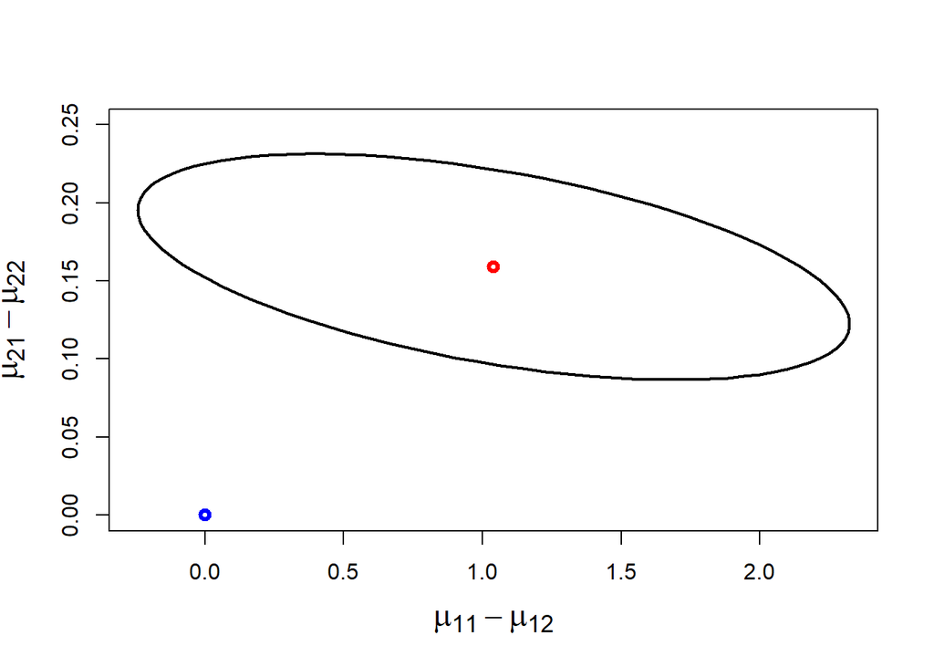

```r
##################################################
library(ellipse)
xbar=barx1-barx2
plot(ellipse(Sp/(n1+n2-2),  centre = xbar, t=sqrt(c2)),type="l",lwd=2 ,cex.lab = 1.5,
     ylim=c(0,0.25),xlab=expression(mu[11]-mu[12]),
     ylab=expression(mu[21]-mu[22]))
points(xbar[1],xbar[2],col="red", lwd=3)
points(0,0,col="blue", lwd=3)
```